# Midterm Group Project, Stats 506, F20

Hongfan Chen

十一月 24, 2020

```r
suppressPackageStartupMessages({
  library(tidyverse)
})
```

### README

In this `SAS` tutorial, we mainly use the following procedure. `proc import` and `macros` `csvexport`(Contributed by Dr.Henderson) are used to read and export the data. `proc logistic` is used to fit the logistic regression model and predicts propensity score, and `gmatch`(Contributed by The Division of Biostatistics at the Mayo Clinic) perfroms the greedy matching.

Then we use `proc gchart` to reveal the structure of the data, thereafter using `proc means` along with `proc ttest` to compute means and construct the t-test with sample weight.

This work is done primarily in `SAS`, with the exception that the write up and figures or tables for visualization are produced in R.

### SAS Script

**`GroupProject_SAS_Hongfan.sas`**

```r
readLines("./GroupProject_SAS_Hongfan.sas")
```

```
  [1] "/* Midterm Group Project "
  [2] " * Stats 506, Fall 2020"
  [3] " * "
  [4] " * Topic: Creating propensity score weights and using inverse propensity "
  [5] " * weights and/or matching for analysis."
  [6] " * "
  [7] " * Question: Whether or not adult patients with diabetes have higher risk for"
  [8] " * heart attack (myocardial infarction) in the United States?"
  [9] " * "
 [10] " * Updated: November 11, 2020"
 [11] " * Author: Hongfan Chen"
 [12] " * Group: Group 1"
 [13] " * "
 [14] " */ "
 [15] ""
```

[output cut: 373 more lines]

### Load Files

```r
path = './'
prematch_path = sprintf('%s/output/freq_table.csv', path)
matched_path = sprintf('%s/output/freq_table_merge.csv', path)
inverseweight_path = sprintf('%s/output/ps_match_inverse_table.csv', path)
matched_sum_path = sprintf('%s/output/matched_summary.csv', path)
pre_sum_path = sprintf('%s/output/pre_summary.csv', path)
conflimits_path = sprintf('%s/output/conflimits.csv', path)
ttest_path = sprintf('%s/output/ttest.csv', path)

age_pre = sprintf('%s/graph/age_before.png', path)
age_after = sprintf('%s/graph/age_after.png', path)

hyper_pre = sprintf('%s/graph/hyper_before.png', path)
hyper_after = sprintf('%s/graph/hyper_after.png', path)

smoke_pre = sprintf('%s/graph/smoke_before.png', path)
smoke_after = sprintf('%s/graph/smoke_after.png', path)

press1_pre = sprintf('%s/graph/press_before.png', path)
press1_after = sprintf('%s/graph/press_after.png', path)

press2_pre = sprintf('%s/graph/press2_before.png', path)
press2_after = sprintf('%s/graph/press2_after.png', path)

ps_distribution = sprintf('%s/graph/ps_combined.png', path)

prematch = read_delim(prematch_path, delim = ',')
matched = read_delim(matched_path, delim = ',')
inverseweight = read_delim(inverseweight_path, delim = ',')
matched_sum = read_delim(matched_sum_path, delim = ',')
pre_sum = read_delim(pre_sum_path, delim = ',')
conflimits = read_delim(conflimits_path, delim = ',')
ttest = read_delim(ttest_path, delim = ',')
```

### 1. Distribution of Propensity Score

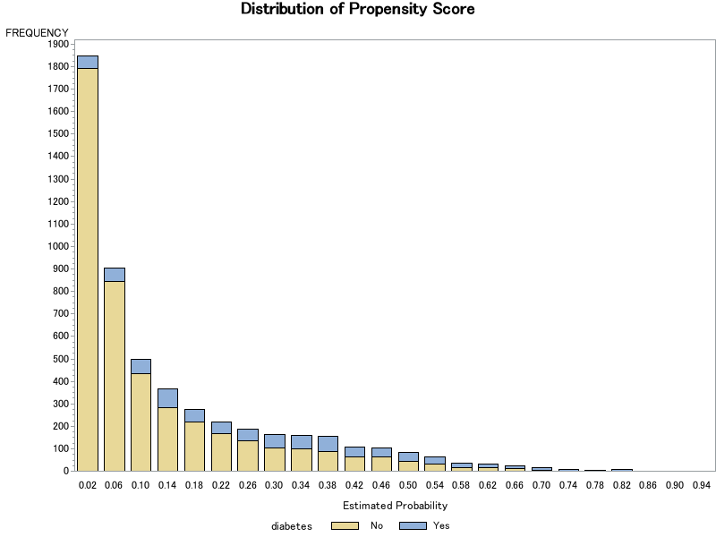

```r
knitr::include_graphics(ps_distribution)
```

### Explanation

From the figure above, we see that there is a huge difference in the distribution of propensity score of two groups. If we compare the heart attack rate directly, a misleading result may occur. Therefore, we need to implement the Propensity Score Matching/Weighting to achieve balance or comparability of treatment groups in terms of their measured pretreatment covariates, and thereby controls for confounding bias in estimating treatment effects.

### 2. Comparison Table Between Prematch Data And Macthed Data

```r
tab = function(df, cap = "hello"){
  df %>%
  mutate(
    `Heart Attack` = ifelse(heart_attack == 1, "YES", "NO"),
    diabetes = ifelse(diabetes == 1, "Diabetes", "Non-Diabetes")
    ) %>%
  group_by(diabetes) %>%
  mutate(pct = COUNT / sum(COUNT)) %>%
  mutate(COUNT_PCT = sprintf('%.0f (%.2f%s)', COUNT, pct * 100, "%")) %>%
  select(`Heart Attack`, diabetes, COUNT_PCT) %>%
  pivot_wider(id_cols = `Heart Attack`,
               names_from = 'diabetes',
               values_from = 'COUNT_PCT') %>%
  knitr::kable(format = 'html', caption = cap) %>%
  kableExtra::kable_styling("striped", full_width = TRUE)
}
```

#### Before Match

```r
cap = paste0(
"**Table 1.** Proportion of Heat Attack with Pre-matched Group"
)
tab(prematch,
    cap = cap
    )
```

**Table 1.** Proportion of Heat Attack with Pre-matched Group

| Heart Attack | Non-Diabetes | Diabetes |
| --- | --- | --- |
| NO | 195463600 (97.80%) | 22122559 (85.24%) |
| YES | 4398495 (2.20%) | 3830884 (14.76%) |

#### After Match

```r
cap = paste0(
"**Table 2.** Proportion of Heat Attack with Matched Group"
)
tab(matched,
    cap = cap
    )
```

**Table 2.** Proportion of Heat Attack with Matched Group

| Heart Attack | Non-Diabetes | Diabetes |
| --- | --- | --- |
| NO | 27811682 (95.02%) | 21877563 (85.45%) |
| YES | 1458481 (4.98%) | 3724941 (14.55%) |

#### Using Iverse Propensity Weight

```r
cap = paste0(
"**Table 3.** Proportion of Heat Attack with Inverse Propensity Weight"
)
tab(inverseweight,
    cap = cap
    )
```

**Table 3.** Proportion of Heat Attack with Inverse Propensity Weight

| Heart Attack | Non-Diabetes | Diabetes |
| --- | --- | --- |
| NO | 220195127 (97.38%) | 209962324 (94.17%) |
| YES | 5934456 (2.62%) | 13009527 (5.83%) |

### Explanation

These tables show how `Propensity Score Matching/Weighting` eliminate or reduce the effect of pre-treatment covariates on estimating treatment effect.  
We can see that before matching/weighting, the rate of heart attack in diabetes patients is around 7 times larger than the non-diabetes patients. After matching/weighting, this rate decreases to only 2-3 times larger. This tells us the diabetes does have an effect on heart attack, but not that much.

### 3. Comparison Graph Between Prematch Data And Macthed Data

#### Age

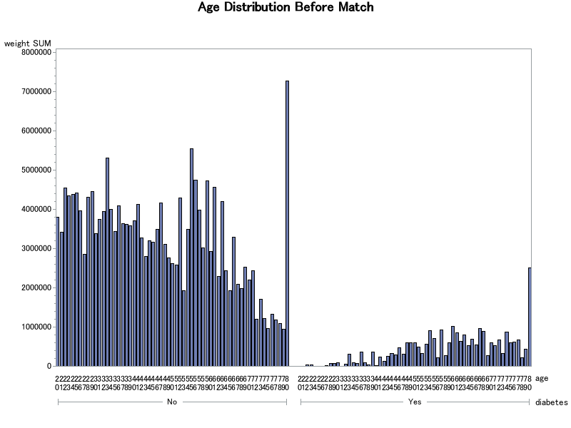

```r
knitr::include_graphics(age_pre)
```

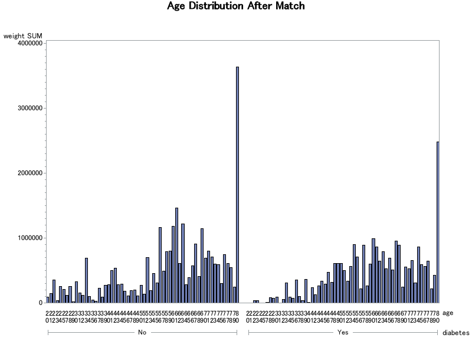

```r
knitr::include_graphics(age_after)
```

#### Year of Hyper

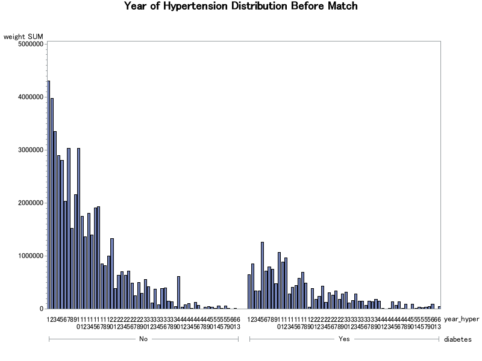

```r
knitr::include_graphics(hyper_pre)
```

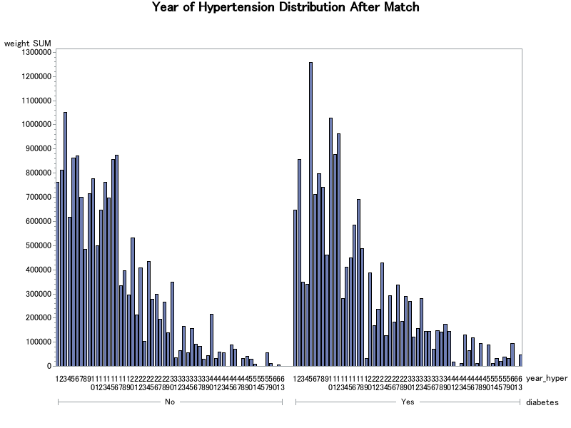

```r
knitr::include_graphics(hyper_after)
```

#### Year of Smoke

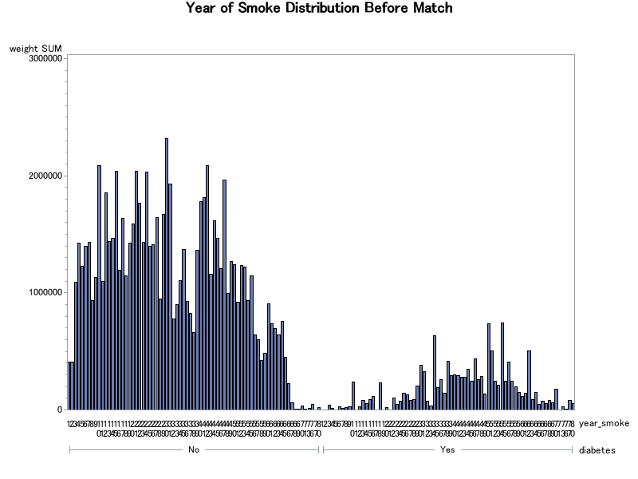

```r
knitr::include_graphics(smoke_pre)
```

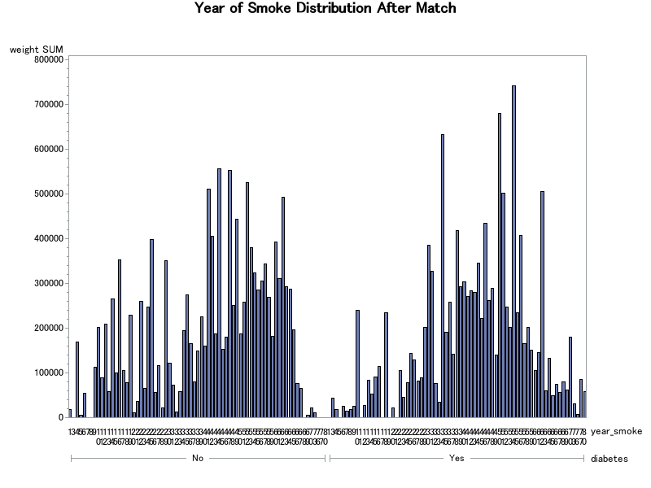

```r
knitr::include_graphics(smoke_after)
```

#### Blood Press

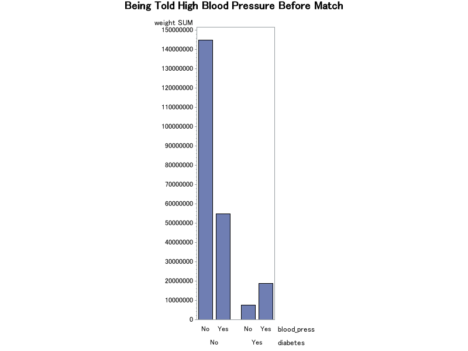

```r
knitr::include_graphics(press1_pre)
```

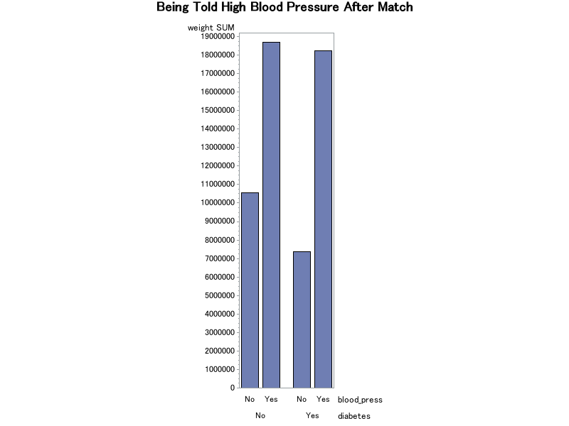

```r
knitr::include_graphics(press1_after)
```

#### Blood Press 2

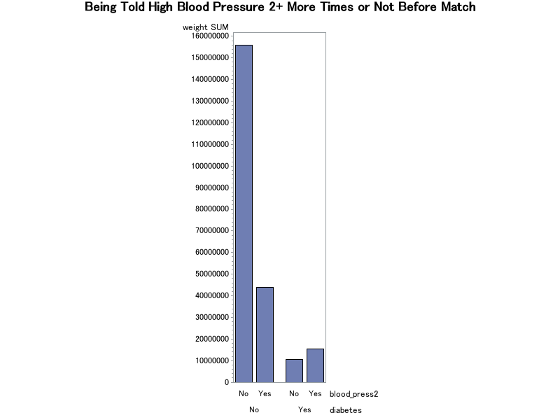

```r
knitr::include_graphics(press2_pre)
```

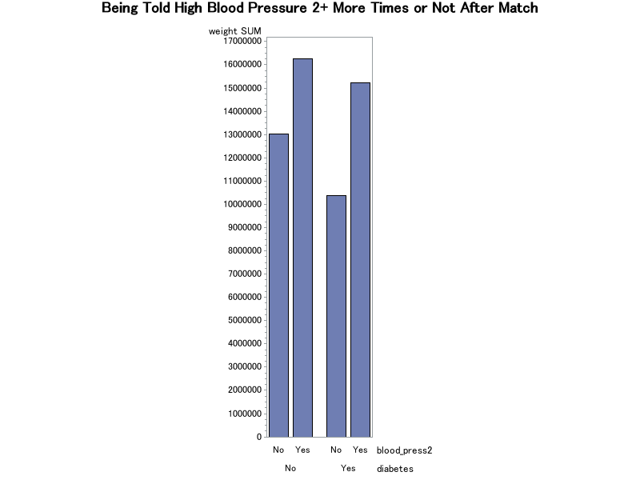

```r
knitr::include_graphics(press2_after)
```

### Explanation

These graphs give us a direct and clear sense of how `Propensity Score Matching/Weighting` balance the pre-treatment covariates. Here I select `age`, `year of smoke`, `year of hyper`, `blood pressure` to illustrate this fact. Before matching, the distribution of these variables differs heavily on two groups. After matching, these pre-treatment covariates seems to be unified, which helps us to mimic the situations of Randomized clinical trials(RCT).

### 4. Balance Checking For All Covariates And T Test

#### MEAN/STD

```r
n = (length(names(matched_sum)) - 1) / 3
pre_data = NULL
matched_data = NULL

for(i in 1:n){
  data0 = pre_sum %>%
    select(1, 2+3*(i-1), 3+3*(i-1), 4+3*(i-1))
  names(data0) = c("diabetes", "variable", "mean", "std")
  data_wider = data0 %>%
    mutate(mean_std = sprintf("%.3f(%.3f)", mean, std),
           diabetes = ifelse(diabetes == "Yes",
                             "Diabetes",
                             "Non-diabetes")
    ) %>%
    select(diabetes, variable, mean_std) %>%
    pivot_wider(names_from = diabetes,
                values_from = mean_std)
  pre_data = bind_rows(pre_data, data_wider)
}

for(i in 1:n){
  data0 = matched_sum %>%
    select(1, 2+3*(i-1), 3+3*(i-1), 4+3*(i-1))
  names(data0) = c("diabetes", "variable", "mean", "std")
  data_wider = data0 %>%
    mutate(mean_std = sprintf("%.3f(%.3f)", mean, std),
           diabetes = ifelse(diabetes == "Yes",
                             "Diabetes",
                             "Non-diabetes")
           ) %>%
    select(diabetes, variable, mean_std) %>%
    pivot_wider(names_from = diabetes,
                values_from = mean_std)
  matched_data = bind_rows(matched_data, data_wider)
}

tab = left_join(pre_data, matched_data, by = "variable")
cap_tab = paste(
  "**Table 4.** *The mean of all variables before and after matching.*",
  "Numbers in parantheses are standard deviation."
)
cn = c('Covariate',
       'Non-diabetes', 'diabetes',
       'Non-diabetes', 'Non-diabetes'
       )
tab %>%
  knitr::kable(
    format = 'html',
    escape = FALSE,
    align = 'lcccc',
    col.names = cn,
    cap = cap_tab
  ) %>%
  kableExtra::kable_styling("striped", full_width = TRUE) %>%
  kableExtra::add_header_above(header = c(' ' = 1,
                                          'Before Matching' = 2,
                                          'After Matching' = 2)
                               )
```

**Table 4.** *The mean of all variables before and after matching.* Numbers in parantheses are standard deviation.

[output not shown]

#### T-TEST

```r
tab1 = conflimits %>%
  select(Variable, Class, Method, Variances, Mean) %>%
  left_join(ttest %>%
              select(-Variable),
            by = c("Method", "Variances")
            ) %>%
  replace_na(list(Method = "-",
                  Variances = "-",
                  tValue = "-",
                  DF = "-",
                  Probt = "-")
             )
cap_tab1 = paste(
  "**Table 5.** *Perform t test to show significance using two method.*",
  "Diabetes indeed has an effect on heart attack."
)
tab1 %>%
  knitr::kable(format = 'html', caption = cap_tab1) %>%
  kableExtra::kable_styling("striped", full_width = TRUE)
```

**Table 5.** *Perform t test to show significance using two method.* Diabetes indeed has an effect on heart attack.

Variable

Class

Method

Variances

Mean

tValue

DF

Probt

heart_attack

No

0.0498

heart_attack

Yes

0.1455

heart_attack

Diff (1-2)

Pooled

Equal

-0.0957

-6.67

1626

<.0001

heart_attack

Diff (1-2)

Satterthwaite

Unequal

-0.0957

-6.58

1353.8

<.0001

### Explanation

Finally, I provides two tables here. The first one is the mean-std pairs of all covariates which shows the difference of two groups. The second one shows the t test result, which indicates that after matching, the heart attack rate in diabetes patients is still higher than the non-diabetes patients.  
So now we can answer the question at the beginning: Adult patients with diabetes do have higher risk for heart attack (myocardial infarction) in the United States.